# Logistic Regression in R

Ryan Slipe

2025-01-01

## Logistic Regression

First we will upload our data and preprocess it for modeling. At first glance, we can see that the column names are not listed. We can get these names from the website and make a variable dictionary to store the column names and what they mean.

```r
# add libraries we will be using
library(ggplot2)
library(cowplot)
# read in the data
data <- read.csv('processed.cleveland.data', header = FALSE)

# first 6 rows - no column names listed
head(data)
```

```
##   V1 V2 V3  V4  V5 V6 V7  V8 V9 V10 V11 V12 V13 V14
## 1 63  1  1 145 233  1  2 150  0 2.3   3 0.0 6.0   0
## 2 67  1  4 160 286  0  2 108  1 1.5   2 3.0 3.0   2
## 3 67  1  4 120 229  0  2 129  1 2.6   2 2.0 7.0   1
## 4 37  1  3 130 250  0  0 187  0 3.5   3 0.0 3.0   0
## 5 41  0  2 130 204  0  2 172  0 1.4   1 0.0 3.0   0
## 6 56  1  2 120 236  0  0 178  0 0.8   1 0.0 3.0   0
```

## Variable Dictionary

| variable | definition |
| --- | --- |
| age | age of patient |
| sex | 0 female 1 male |
| cp | chest pain- 1 = typical angina, 2 = atypical angina, 3 = non-anginal pain, 4 = asymptomatic |
| trestbps | resting blood pressure (in mm Hg) |
| chol | serum cholestoral in mg/dl |
| fbs | fasting blood sugar if less than 120 mg/dl 1 = TRUE, 0 = FALSE |
| restecg | resting electrocardiographic results 1 = normal, 2 = having ST-T wave abnormality 3 = showing probable or definite left ventricular hypertrophy |
| thalach | maximum heart rate achieved |
| exang | exercise induced angina, 1 = yes, 0 = no |
| oldpeak | ST depression induced by exercise relative to rest |
| slope | the slope of the peak exercise ST segment 1 = upsloping, 2 = flat, 3 = downsloping |
| ca | number of major vessels (0-3) colored by fluoroscopy |
| thal | short of thalium heart scan 3 = normal (no cold spots), 6 = fixed defect (cold spots during rest and exercise) 7 = reversible defect (when cold spots only appear during exercise) |
| hd | target variable heart disease. 0 for healthy 1 for unhealthy |

```r
# add column names listed on website
colnames(data) <- c(
  "age",
  "sex",
  "cp",
  "trestbps",
  "chol",
  "fbs",
  "restecg",
  "thalach",
  "exang",
  "oldpeak",
  "slope",
  "ca",
  "thal",
  "hd"
)

# view data structure
str(data)
```

```
## 'data.frame':    303 obs. of  14 variables:
##  $ age     : num  63 67 67 37 41 56 62 57 63 53 ...
##  $ sex     : num  1 1 1 1 0 1 0 0 1 1 ...
##  $ cp      : num  1 4 4 3 2 2 4 4 4 4 ...
##  $ trestbps: num  145 160 120 130 130 120 140 120 130 140 ...
##  $ chol    : num  233 286 229 250 204 236 268 354 254 203 ...
##  $ fbs     : num  1 0 0 0 0 0 0 0 0 1 ...
##  $ restecg : num  2 2 2 0 2 0 2 0 2 2 ...
##  $ thalach : num  150 108 129 187 172 178 160 163 147 155 ...
##  $ exang   : num  0 1 1 0 0 0 0 1 0 1 ...
##  $ oldpeak : num  2.3 1.5 2.6 3.5 1.4 0.8 3.6 0.6 1.4 3.1 ...
##  $ slope   : num  3 2 2 3 1 1 3 1 2 3 ...
##  $ ca      : chr  "0.0" "3.0" "2.0" "0.0" ...
##  $ thal    : chr  "6.0" "3.0" "7.0" "3.0" ...
##  $ hd      : int  0 2 1 0 0 0 3 0 2 1 ...
```

The structure of the data shows that some of the variables do not match the data type listed on the UCI Repository. We will fix these now.

```r
# change sex category to 0 - Female and 1 - Male
data[data$sex == 0,]$sex <- 'F'
data[data$sex == 1,]$sex <- 'M'

# change sex column to categorical
data$sex <- as.factor(data$sex)

# cp, rbs, restecg, exang, and slope are all supposed to be factors
data$cp <- as.factor(data$cp)
data$fbs <- as.factor(data$fbs)
data$exang <- as.factor(data$exang)
data$slope <- as.factor(data$slope)

# ca is also categorical but has question marks so change this - remember NA values exist here
data$ca <- as.integer(data$ca)
data$ca <- as.factor(data$ca)

# thal has NA values but should be categorical
data$thal <- as.integer(data$thal)
data$thal <- as.factor(data$thal)

# change hd column to 0 for healthy and 1 for unhealthy with ifelse
data$hd <- ifelse(test = data$hd == 0, yes = 'Healthy', no = 'Unhealthy')
```

There are only 6 rows with NA values so we will remove them by filtering the data.

```r
# number of missing rows in ca and thal - only 6 so they can be removed
nrow(data[is.na(data$ca) | is.na(data$thal),])
```

```
## [1] 6
```

```r
# view these rows
data[is.na(data$ca) | is.na(data$thal),]
```

```
##     age sex cp trestbps chol fbs restecg thalach exang oldpeak slope   ca thal
## 88   53   F  3      128  216   0       2     115     0     0.0     1    0 <NA>
## 167  52   M  3      138  223   0       0     169     0     0.0     1 <NA>    3
## 193  43   M  4      132  247   1       2     143     1     0.1     2 <NA>    7
## 267  52   M  4      128  204   1       0     156     1     1.0     2    0 <NA>
## 288  58   M  2      125  220   0       0     144     0     0.4     2 <NA>    7
## 303  38   M  3      138  175   0       0     173     0     0.0     1 <NA>    3
##            hd
## 88    Healthy
## 167   Healthy
## 193 Unhealthy
## 267 Unhealthy
## 288   Healthy
## 303   Healthy
```

```r
# we want all columns but we do not want the rows where the values are NA
data <- data[!(is.na(data$ca) | is.na(data$thal)),]
```

Now we check to see if each categorical variable is represented by each group to make sure that we can use them all. There may be an issue with **restecg** since only 4 observations are represented as level 1, but we will continue forward with using the variable.

```r
# create a tables for heart disease and each variable
xtabs(~ hd + sex, data = data)
```

```
##            sex
## hd            F   M
##   Healthy    71  89
##   Unhealthy  25 112
```

```r
xtabs(~ hd + cp, data = data)
```

```
##            cp
## hd            1   2   3   4
##   Healthy    16  40  65  39
##   Unhealthy   7   9  18 103
```

```r
xtabs(~ hd + fbs, data = data)
```

```
##            fbs
## hd            0   1
##   Healthy   137  23
##   Unhealthy 117  20
```

```r
xtabs(~ hd + restecg, data = data)
```

```
##            restecg
## hd           0  1  2
##   Healthy   92  1 67
##   Unhealthy 55  3 79
```

```r
xtabs(~ hd + exang, data = data)
```

```
##            exang
## hd            0   1
##   Healthy   137  23
##   Unhealthy  63  74
```

```r
xtabs(~ hd + slope, data = data)
```

```
##            slope
## hd            1   2   3
##   Healthy   103  48   9
##   Unhealthy  36  89  12
```

```r
xtabs(~ hd + ca, data = data)
```

```
##            ca
## hd            0   1   2   3
##   Healthy   129  21   7   3
##   Unhealthy  45  44  31  17
```

```r
xtabs(~ hd + thal, data = data)
```

```
##            thal
## hd            3   6   7
##   Healthy   127   6  27
##   Unhealthy  37  12  88
```

```r
xtabs(~ hd + restecg, data = data)
```

```
##            restecg
## hd           0  1  2
##   Healthy   92  1 67
##   Unhealthy 55  3 79
```

## Our First Model

```r
# make predictor variable a factor
data$hd <- as.factor(data$hd)

# create model
logistic <- glm(hd ~ sex, data = data, family = 'binomial')
# view results
summary(logistic)
```

```
##
## Call:
## glm(formula = hd ~ sex, family = "binomial", data = data)
##
## Deviance Residuals:
##     Min       1Q   Median       3Q      Max
## -1.2765  -1.2765  -0.7768   1.0815   1.6404
##
## Coefficients:
##             Estimate Std. Error z value Pr(>|z|)
## (Intercept)  -1.0438     0.2326  -4.488 7.18e-06 ***
## sexM          1.2737     0.2725   4.674 2.95e-06 ***
## ---
## Signif. codes:  0 '***' 0.001 '**' 0.01 '*' 0.05 '.' 0.1 ' ' 1
##
## (Dispersion parameter for binomial family taken to be 1)
##
##     Null deviance: 409.95  on 296  degrees of freedom
## Residual deviance: 386.12  on 295  degrees of freedom
## AIC: 390.12
##
## Number of Fisher Scoring iterations: 4
```

#### Deviance Residuals

Deviance Residuals:

```
Min          1Q         Median          3Q          Max

-1.2765     -1.2765     -0.7768       1.0815      1.6404
```

#### Coefficients

Since we are only using **sex** as a predictor of **hd**, the intercept is the log(odds) that a female will have heart disease. Since this is a negative value it tells us that females are healthier than males in this data set. In R the factors are ordered alphabetically which is how we know this.

The coefficient **sexM** is a log(odds ratio). The odds ratio is the odds(Male Unhealthy) over odds(Female Unhealthy). It tells us that the odds of a male being unhealthy are 1.27 times greater than that of a female on a log scale. Coefficients:

```
            Estimate Std. Error z value Pr(>|z|)
(Intercept)  -1.0438     0.2326  -4.488 7.18e-06 ***
sexM          1.2737     0.2725   4.674 2.95e-06 ***
```

We can confirm these numbers manually. Using the xtabs table from above we see that there are 25 unhealthy females and 71 healthy females. We also see that there are 112 unhealthy males and 89 healthy males.

```r
# odds of a female being unhealthy
female_log_odds <- log(25 / 71)
female_log_odds
```

```
## [1] -1.043804
```

```r
# odds ratio unhealthy male unhealthy female
male_odds_ratio <- log((112 / 89) / (25 / 71))
male_odds_ratio
```

```
## [1] 1.273667
```

## Finding R-Squared for Logistic Regression

To find the R-squared value for logistic regression we need the log-likelihood of the null model, saturated model, and proposed model but the saturated model is 0 so we can remove that from our calculations. The LL(null) tells us how well the null model fits the data. The null model is a poor model with no predictors. It is similar to the Sum of Squares of the Mean for linear regression. This number should be a larger negative number than the LL(proposed) since it tells us about fitting the data. Since we have the null deviance we can use this to find the LL(null). We will also be using the LL(proposed) model which is the log likelihood of our fitted model. The log likelihood of the proposed model tells us how well this model fits the data and will be compared to the LL(null). It should be a small negative number closer to 0 than the LL(null).

We are given the Null Deviance and the Residual Deviance so we can get the LL(null) model by dividing the null deviance by -2. The LL(proposed) can be found by dividing the residual deviance by -2.

Null Deviance
$$\text{Null deviance} = 2 \times (\text{LogLikelihood(saturated model)} -
\text{LogLikelihood(null model)}) \\
= -2 \times \text{LogLikelihood(null model)}$$

Residual Deviance
$$\text{Residual deviance} = 2 \times (\text{LogLikelihood(saturated
model)} - \text{LogLikelihood(proposed model)}) \\
= -2 \times \text{LogLikelihood(proposed
model)}$$

### McFadden’s Psuedo R-Squared

McFadden’s Pseudo R-squared is calculated as:
$$R^2_{McFadden} = 1 -
\frac{\text{LogLikelihood(Proposed)}}{\text{LogLikelihood(Null)}}$$

This formula ensures that the range is from 0 to 1 just like linear regression r-squared values. It is the proportion of the log likelihood explained by the proposed model relative to the null model, meaning a larger number means a better fit. It can be thought of as a measure of improvement of fit the proposed model has on the null model, or the amount of uncertainty in the null model that has been accounted for in the proposed model.

```r
# calculate the log likelihood of the null model
ll_null <- logistic$null.deviance / -2
ll_proposed <- logistic$deviance / -2

# calculate the r squared
r_squared = 1 - (ll_proposed / ll_null)
r_squared
```

```
## [1] 0.05812569
```

### Likelihood Ratio Test

The likelihood ratio test is another goodness-of-fit test that we can use for logistic regression that is similar to a p-value for an R-squared value in linear regression. This is because the likelihood ratio test compares the fit of the null model and the proposed model to see if they are significantly different and we used them to determine the pseudo r-squared.
$$\chi^2 = 2 \times
(\text{LogLikelihood(Proposed)} -
\text{LogLikelihood(Null)})$$

The resulting chi-squared value is used to find if the two models are significantly different or not. The degrees of freedom is the difference in the number of parameters in the two models (LL(null) has 1.) We can obtain the degrees of freedom right from the model by getting the length of **logistic$coefficients** - 1.

```r
# pchisq gives the area up til our test value but we want the rest so we use 1 - pchisq
p_val = 1 - pchisq(2*(ll_proposed - ll_null), df = (length(logistic$coefficients)- 1))
p_val
```

```
## [1] 1.053157e-06
```

The results are interesting. We see a very small R-squared value which tells us that our model does not explain much more variability than that of the null model (only %5). However, the p-value in the likelihood ratio test is less than 0.05 which tells us that the proposed model improvement is statistically significant to the null model. We can interpret this as the model not fitting the overall data well since it only captures %5 of the variability, but the added **sex** coefficient did improve the model in a statistically significant way meaning we are on the right track but should try to find more variables that can explain the variance.

### Graphing the Data

Now we can see how our model performs on the given data. For this very simple model we will only have two possible probabilities since there is only 1 variable with two possible outcomes. There is the probability of a female having heart disease and the probability of a male having heart disease.

```r
predictions <- data.frame(
  proba <- logistic$fitted.values,
  sex <- data$sex)
head(predictions)
```

```
##   proba....logistic.fitted.values sex....data.sex
## 1                       0.5572139               M
## 2                       0.5572139               M
## 3                       0.5572139               M
## 4                       0.5572139               M
## 5                       0.2604167               F
## 6                       0.5572139               M
```

If we plot this data we will not see the normal s-curve for logistic regression because we are dealing with a binary predictor variable.

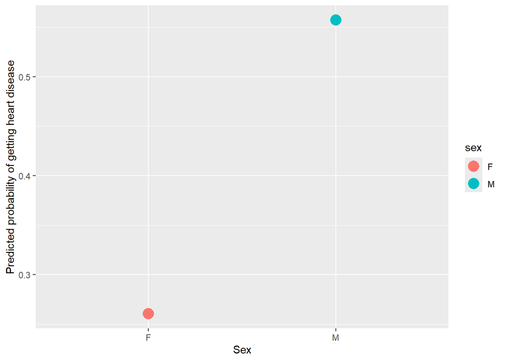

```r
# plot
ggplot(data=predictions, aes(x=sex, y=proba)) +
  geom_point(aes(color=sex), size=5) +
  xlab("Sex") +
  ylab("Predicted probability of getting heart disease")
```

```r
# summary
xtabs(~ proba + sex, data=predictions)
```

```
##                    sex
## proba                 F   M
##   0.260416666667241  96   0
##   0.55721393034826    0 201
```

#### Complex Model

Now, we will create a model using all variables.

```r
# fit the model
logistic <- glm(hd ~ ., family = 'binomial', data = data)
summary(logistic)
```

```
##
## Call:
## glm(formula = hd ~ ., family = "binomial", data = data)
##
## Deviance Residuals:
##     Min       1Q   Median       3Q      Max
## -3.0501  -0.4820  -0.1214   0.3068   2.9116
##
## Coefficients:
##              Estimate Std. Error z value Pr(>|z|)
## (Intercept) -6.254730   2.960710  -2.113 0.034637 *
## age         -0.023357   0.025132  -0.929 0.352690
## sexM         1.658981   0.551044   3.011 0.002607 **
## cp2          1.453169   0.808899   1.796 0.072418 .
## cp3          0.397509   0.700289   0.568 0.570282
## cp4          2.379571   0.708739   3.357 0.000787 ***
## trestbps     0.027893   0.011686   2.387 0.016989 *
## chol         0.004444   0.004084   1.088 0.276502
## fbs1        -0.581497   0.592874  -0.981 0.326686
## restecg      0.243138   0.198280   1.226 0.220110
## thalach     -0.019871   0.011701  -1.698 0.089474 .
## exang1       0.651696   0.447353   1.457 0.145176
## oldpeak      0.399087   0.237201   1.682 0.092475 .
## slope2       1.298993   0.485834   2.674 0.007501 **
## slope3       0.608301   0.937727   0.649 0.516534
## ca1          2.238802   0.514601   4.351 1.36e-05 ***
## ca2          3.264386   0.785488   4.156 3.24e-05 ***
## ca3          2.202742   0.925827   2.379 0.017350 *
## thal6       -0.163671   0.807500  -0.203 0.839379
## thal7        1.431115   0.440454   3.249 0.001157 **
## ---
## Signif. codes:  0 '***' 0.001 '**' 0.01 '*' 0.05 '.' 0.1 ' ' 1
##
## (Dispersion parameter for binomial family taken to be 1)
##
##     Null deviance: 409.95  on 296  degrees of freedom
## Residual deviance: 183.19  on 277  degrees of freedom
## AIC: 223.19
##
## Number of Fisher Scoring iterations: 6
```

The Akaike Information Criterion (AIC) value for this model is lower than our baseline model which tells us that adding the extra parameters results in a better fit without being overly complex. The formula for AIC is:
$$\text{AIC} = 2k - 2 \ln(L)$$
. K is equal to the number of parameters and L is the likelihood of the proposed model. This formula penalizes models with a high number of parameters in the first portion (2k) and subtracts that from the goodness of fit. A high AIC tells us that the model is either too complex or does not fit the data well.

Let’s get the LL(null) and LL(proposed) from this new model and compute the R-squared.

```r
# calculate the log likelihood of the null model
ll_null <- logistic$null.deviance / -2
ll_proposed <- logistic$deviance / -2

# calculate the r squared
r_squared = 1 - (ll_proposed / ll_null)
r_squared
```

```
## [1] 0.5531417
```

Just as we did with the simple model we will do a log likelihood ratio test to see if this model is statistically different from the null model. The p-value is so small that R has labeled it as 0 meaning this model fit is statistically significant in relation to the null model and means the added predictors are significant in helping with predictions.

```r
# get the test stat from chi-squared and calc upper tail
1 - pchisq(2*(ll_proposed - ll_null), df = length(logistic$coefficients - 1))
```

```
## [1] 0
```

#### Visualizing Performance

The visualization of the model shows that the model does a pretty good job of predicting heart disease for patients. Most of the pink colored data is below the 50% threshold and most of the blue data is above the 50% decision threshold. The colors are the actual outcomes and the y-axis label is the probability of having heart disease from our model so any point below the 50% mark would be labeled pink by our model and any point above the 50% mark would be labeled blue.

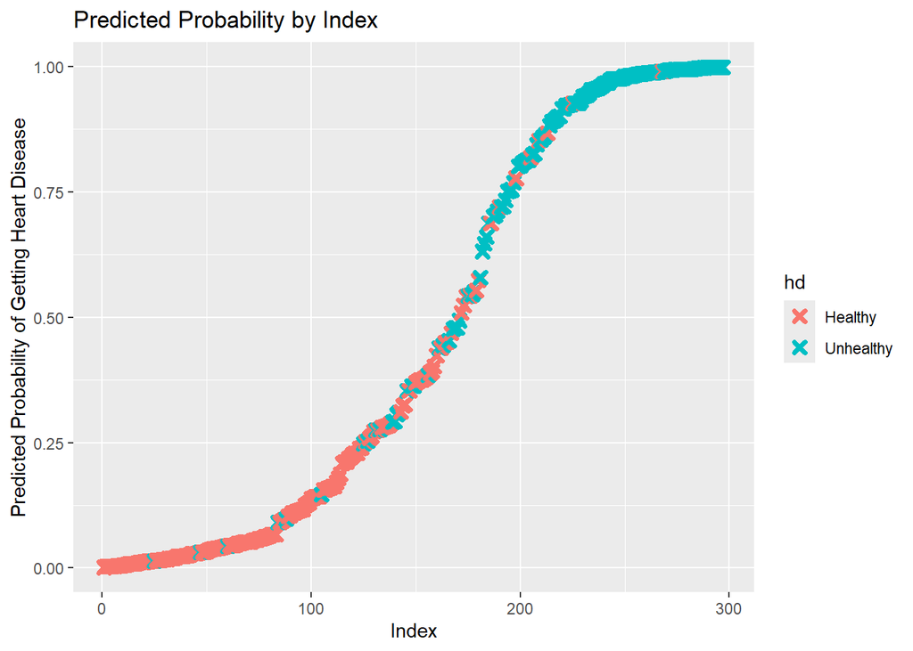

```r
# dataframe of predicted probabilities
predictions <- data.frame(
  proba = logistic$fitted.values,
  hd = data$hd)

# sort them by rows but don't change columns - ascending order for graphing
predictions <- predictions[order(predictions$proba, decreasing = FALSE),]

# add a column named rank to be used as x-axis
predictions$rank <- 1:nrow(predictions)

ggplot(data=predictions, aes(x=rank, y=proba)) +
  geom_point(aes(color=hd), alpha=1, shape=4, stroke=2) +
  xlab("Index") +
  ylab("Predicted Probability of Getting Heart Disease") +
  ggtitle("Predicted Probability by Index")
```